# Part I - Prosper Dataset Exploration

## Multivariate Exploration

> In this section I will be creating plots of three or more variables to investigate the data even further.

### BorrowerRate, IncomeRange and Term

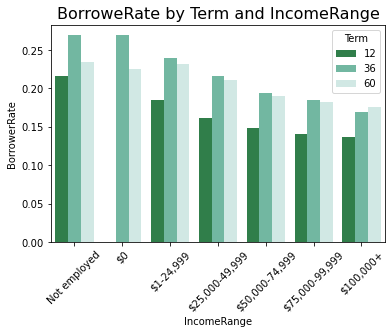

```python
sb.barplot(data=df_final, x='IncomeRange', y='BorrowerRate', hue='Term',ci=None, palette='BuGn_r');
plt.title('BorroweRate by Term and IncomeRange', fontdict={'size':16})
plt.xticks(rotation=45);
```

> **Remark:** This chart shows that for all three Terms there is a general decrease in BorrowerRate as the IncomeRange increases.

### Year, BorrowerRate and IncomeVerifiable

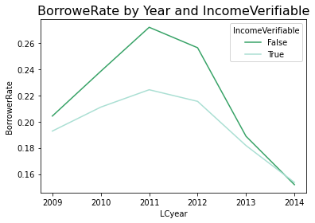

```python
sb.lineplot(data=df_final, x='LCyear', y='BorrowerRate', hue='IncomeVerifiable', palette='BuGn_r', ci=None);
plt.title('BorroweRate by Year and IncomeVerifiable', fontdict={'size':16});
```

> **Remark:** Generally, over the years, those with verifiable income appear to have a lower BorrowerRate.

### Year, BorrowerRate and Term

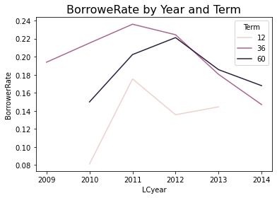

```python
sb.lineplot(data=df_final, x='LCyear', y='BorrowerRate', hue='Term',ci=None)#, palette='BuGn_r');
plt.title('BorroweRate by Year and Term', fontdict={'size':16});
```

> **Remark:** The chart shows that across the years, the 12month term has the smallest BorrowerRate with 60months having the next best rate until after 2012 where the rate for 36months becomes better.

### ProsperScore, Borrower and LoanStatus

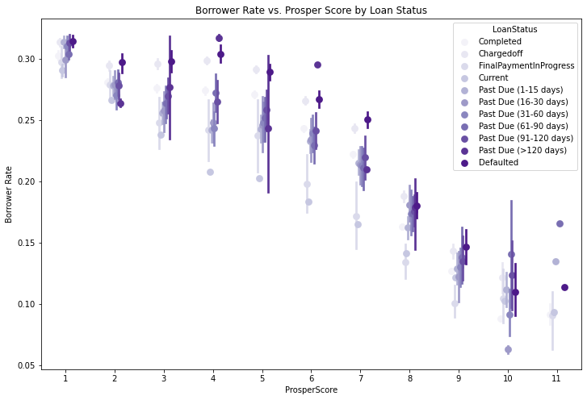

```python
fig = plt.figure(figsize = [12,8])
ax = sb.pointplot(data = df_final, x = 'ProsperScore', y = 'BorrowerRate', hue = 'LoanStatus',
           palette = 'Purples', linestyles = '', dodge = 0.3)
plt.title('Borrower Rate vs. Prosper Score by Loan Status')
plt.ylabel('Borrower Rate')
plt.show();
```